# Text mining - Bag of Words model and Text Visualisation on Cars Recall News

# Pyramid plot

Pyramid Plot is used to find out more if occurence of words between 2 corpus. From this chart below, we notice that both airbag and takata appears more frequently in the 2 corpus.

```r
# Identify terms shared by both documents
common_words <- subset(
  all_m,
  all_m[, 1] > 0 & all_m[, 2] > 0
)

head(common_words)
```

```
##               Docs
## Terms          1  2
##   ability      7  1
##   abs          6  3
##   acadia       5  2
##   accelerates  1  1
##   acceleration 6 13
##   accelerator  4  3
```

```r
# calc common words and difference
difference <- abs(common_words[, 1] - common_words[, 2])
common_words <- cbind(common_words, difference)
common_words <- common_words[order(common_words[, 3],
                                   decreasing = T), ]
head(common_words)
```

```
##             1   2 difference
## risk      439  12        427
## crash     370   4        366
## suvs      340  36        304
## inflators 275   4        271
## airbag    379 134        245
## sedans    261  30        231
```

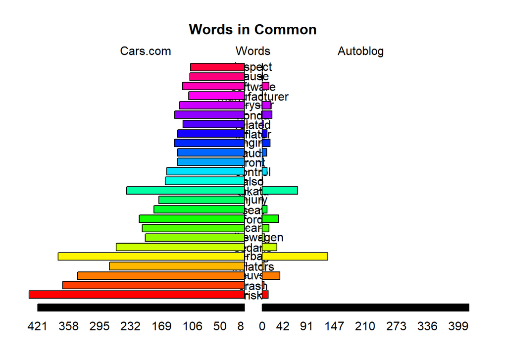

```
## [1] 5.1 4.1 4.1 2.1
```

```r
top25_df <- data.frame(x = common_words[1:25, 1],
                       y = common_words[1:25, 2],
                       labels = rownames(common_words[1:25, ]))

# The plotrix package has been loaded

# Make pyramid plot
pyramid.plot(top25_df$x, top25_df$y,
             labels = top25_df$labels,
             main = "Words in Common",
             gap = 18,
             laxlab = NULL,
             raxlab = NULL,
             unit = NULL,
             top.labels = c("Cars.com",
                            "Words",
                            "Autoblog")
)
```

# Dendogram

A hierachial clustering is done on autoblog dataset. Euclidean distance is used for this model.

```r
# Create word network
# say we want to know moe about a particular faiure such as fire

#word_associate(
#  content_text,
#  match.string = c("takata"),
#  stopwords = all_stops,
#  network.plot = T,
#  cloud.colors = c("gray85", "darkred")
#  )

# WORD CLUSTERING (1st level)

#i am going to perform word cluster on autblog data

# Making the document term matrix:

content_dtm2 <- DocumentTermMatrix(clean_corp2)
content_dtm2
```

```
## <<DocumentTermMatrix (documents: 1404, terms: 1962)>>
## Non-/sparse entries: 7236/2747412
## Sparsity           : 100%
## Maximal term length: 19
## Weighting          : term frequency (tf)
```

```r
#convert the dtm to a matrix: title_m
content_m2 <- as.matrix(content_dtm2)
dim(content_dtm2)
```

```
## [1] 1404 1962
```

```r
content_dtm_rm_sparse2 <- removeSparseTerms(content_dtm2 , 0.98)
# Print out tweets_dtm data
content_dtm_rm_sparse2
```

```
## <<DocumentTermMatrix (documents: 1404, terms: 27)>>
## Non-/sparse entries: 1795/36113
## Sparsity           : 95%
## Maximal term length: 8
## Weighting          : term frequency (tf)
```

```r
content_m2 <- as.matrix(content_dtm_rm_sparse2)
dim(content_m2)
```

```
## [1] 1404   27
```

```r
content_m2[148:159, 10:22]
```

```
##      Terms
## Docs  fire ford fuel honda hyundai ignition issue issues jeep nhtsa nissan
##   148    0    0    0     0       0        0     0      0    1     0      0
##   149    0    0    0     0       0        0     0      0    0     0      0
##   150    0    0    0     0       0        0     0      0    0     0      0
##   151    0    0    0     0       0        0     0      0    0     0      0
##   152    0    0    0     0       0        0     0      0    0     0      1
##   153    0    1    0     0       0        0     0      0    0     0      0
##   154    0    0    0     0       0        0     0      0    0     0      0
##   155    0    0    0     0       0        0     0      0    0     0      0
##   156    0    0    0     0       0        0     1      0    0     0      1
##   157    0    1    0     0       0        0     0      0    0     0      0
##   158    0    0    0     0       0        0     0      0    0     0      0
##   159    0    0    0     0       0        0     0      0    0     0      0
##      Terms
## Docs  risk sedans
##   148    0      0
##   149    0      0
##   150    0      0
##   151    0      0
##   152    0      0
##   153    0      0
##   154    0      0
##   155    0      0
##   156    0      0
##   157    0      0
##   158    0      0
##   159    0      0
```

```r
#making a term document matrix:
content_tdm2 <- TermDocumentMatrix(clean_corp2, control = list(weighting = weightTfIdf))
content_tdm2
```

```
## <<TermDocumentMatrix (terms: 1962, documents: 1404)>>
## Non-/sparse entries: 7236/2747412
## Sparsity           : 100%
## Maximal term length: 19
## Weighting          : term frequency - inverse document frequency (normalized) (tf-idf)
```

```r
contenT_m2 <- as.matrix(content_tdm2)
dim(contenT_m2)
```

```
## [1] 1962 1404
```

```r
contenT_m2[148:159, 10:22]
```

```
##            Docs
## Terms       10 11 12 13 14 15 16 17 18 19 20 21 22
##   bent       0  0  0  0  0  0  0  0  0  0  0  0  0
##   bentaygas  0  0  0  0  0  0  0  0  0  0  0  0  0
##   bentley    0  0  0  0  0  0  0  0  0  0  0  0  0
##   better     0  0  0  0  0  0  0  0  0  0  0  0  0
##   bevy       0  0  0  0  0  0  0  0  0  0  0  0  0
##   big        0  0  0  0  0  0  0  0  0  0  0  0  0
##   bikes      0  0  0  0  0  0  0  0  0  0  0  0  0
##   bill       0  0  0  0  0  0  0  0  0  0  0  0  0
##   billion    0  0  0  0  0  0  0  0  0  0  0  0  0
##   bizarre    0  0  0  0  0  0  0  0  0  0  0  0  0
##   black      0  0  0  0  0  0  0  0  0  0  0  0  0
##   blame      0  0  0  0  0  0  0  0  0  0  0  0  0
```

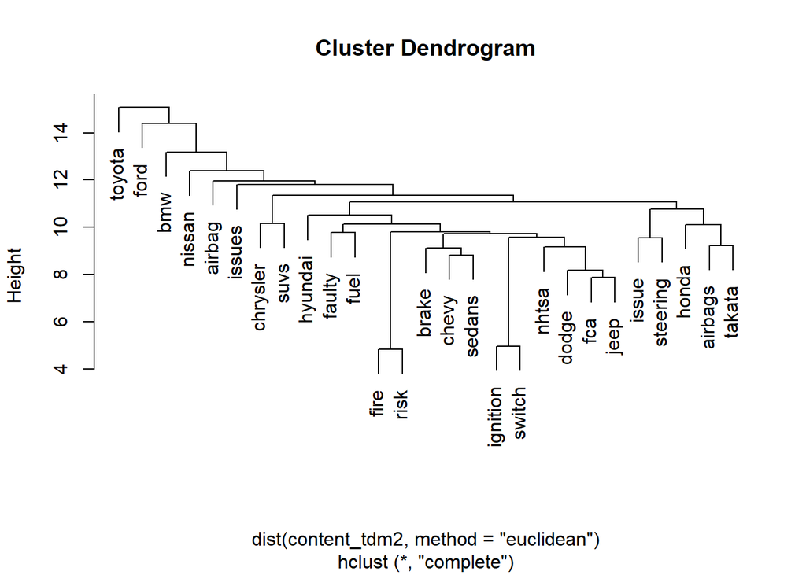

```r
content_tdm2 <- removeSparseTerms(content_tdm2, sparse = 0.98)

hc <- hclust(d = dist(content_tdm2, method = "euclidean"), method = "complete")

# Plot a dendrogram
plot(hc)
```

There might not be strong meaning gather from this dendogram but we can rougly induce that Takata airbags are closely related, followed and Takata airbag in this Dendrogram. When we cross reference to the news article, we found out that in 2018, there was a major recall for various of vechicles which had Takta air bags.

Some other sort of data cleaning is needed before we can perform a good clustering.

# Word Association

Using a function in TM package called findAssocs() to calculate the correlation with other wor in TDM. For example in this case, we want to know how often does Airbag appears with another word.

For any given word, findAssocs() calculates its correlation with every other word in a TDM or DTM. Scores range from 0 to 1. A score of 1 means that two words always appear together, while a score of 0 means that they never appear together.

The function will return a list of all other terms that meet or exceed the minimum threshold. Minimum correlation values are often relatively low because of word diversity. Don’t be surprised if 0.10 demonstrates a strong pairwise term association.

From this example, we learnt that airbag as strong correlation association with takata and honda.

```r
# create word association
# Create associations
associations <- findAssocs(content_tdm2, "airbag", 0.1)

# View the venti associations
associations
```

```
## $airbag
## takata  honda
##   0.23   0.14
```

```r
# Create associations_df
associations_df <- list_vect2df(associations)[, 2:3]
head(associations_df)
```

```
##       X2   X3
## 1  honda 0.14
## 2 takata 0.23
```

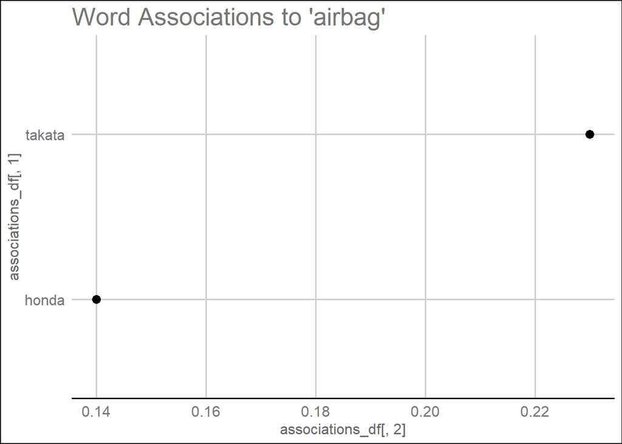

```r
# Plot the associations_df values (don't change this)
ggplot(associations_df, aes(y = associations_df[, 1])) +
  geom_point(aes(x = associations_df[, 2]),
             data = associations_df, size = 3) +
  ggtitle("Word Associations to 'airbag'") +
  theme_gdocs()
```